# Project "Titanic"

## 1. Approach and Dataset

The [data set](https://d17h27t6h515a5.cloudfront.net/topher/2016/September/57e9a84c_titanic-data/titanic-data.csv) was obtained from the Udacity project homepage. It contains demographics and passenger information from 891 of the 2224 passengers and crew on board the Titanic. A brief description of the circumstances of this catastrophe can be viewed on the [Kaggle website](https://www.kaggle.com/c/titanic).

The description of the columns, i.e. a short [data dictionary](https://www.kaggle.com/c/titanic/data), is also available from the Kaggle website. The following table shows its contents:

| Variable | Definition | Key |
| --- | --- | --- |
| survived | Survival | 0 = No, 1 = Yes |
| pclass | Ticket class | 1 = 1st, 2 = 2nd, 3 = 3rd. |
| sex | Sex | male, female |
| Age | Age in years |  |
| sibsp | No. of siblings / spouses aboard the Titanic |  |
| parch | No. of parents / children aboard the Titanic |  |
| ticket | Ticket number |  |
| fare | Passenger fare |  |
| cabin | Cabin number |  |
| embarked | Port of Embarkation | C = Cherbourg, Q = Queenstown, S = Southampton |

fare: Currency not given in the data dictionary, [probably Pound Sterling (£)](http://www.keyflux.com/titanic/facts.htm)

pclass: A proxy for socio-economic status (SES) (1st = Upper, 2nd = Middle, 3rd = Lower)

age: Age is fractional if less than 1. If the age is estimated, is it in the form of xx.5

sibsp: The dataset defines family relations in this way.

- Sibling = brother, sister, stepbrother, stepsister
- Spouse = husband, wife (mistresses and fiancés were ignored)

parch: The dataset defines family relations in this way

- Parent = mother, father
- Child = daughter, son, stepdaughter, stepson
- Some children travelled only with a nanny, therefore parch=0 for them.

## 2. First look at the data set

The following paragraphs give an overall impression of the data set. They show the first 5 records, the most important statistical metrics for the numeric columns and the data types in the data frame.

```python
import matplotlib.pyplot as plt
import numpy as np
import pandas as pd
import seaborn as sns
%matplotlib inline

filename = 'titanic-data.csv'
titanic_df = pd.read_csv(filename, sep=',', header=0, decimal='.',
                         error_bad_lines=True, warn_bad_lines=True, encoding='utf-8')
titanic_df.head(5)
```

|  | PassengerId | Survived | Pclass | Name | Sex | Age | SibSp | Parch | Ticket | Fare | Cabin | Embarked |
| --- | --- | --- | --- | --- | --- | --- | --- | --- | --- | --- | --- | --- |
| 0 | 1 | 0 | 3 | Braund, Mr. Owen Harris | male | 22.0 | 1 | 0 | A/5 21171 | 7.2500 | NaN | S |
| 1 | 2 | 1 | 1 | Cumings, Mrs. John Bradley (Florence Briggs Th... | female | 38.0 | 1 | 0 | PC 17599 | 71.2833 | C85 | C |
| 2 | 3 | 1 | 3 | Heikkinen, Miss. Laina | female | 26.0 | 0 | 0 | STON/O2. 3101282 | 7.9250 | NaN | S |
| 3 | 4 | 1 | 1 | Futrelle, Mrs. Jacques Heath (Lily May Peel) | female | 35.0 | 1 | 0 | 113803 | 53.1000 | C123 | S |
| 4 | 5 | 0 | 3 | Allen, Mr. William Henry | male | 35.0 | 0 | 0 | 373450 | 8.0500 | NaN | S |

Result: The CSV file was read flawlessly without warnings, i.e. all columns were recognized and all values could be interpreted according to their given data type.

The following list shows the data types inferred by pd.read_csv(); they all look sensible when compared to the data dictionary.

```python
titanic_df.dtypes
```

```
PassengerId      int64
Survived         int64
Pclass           int64
Name            object
Sex             object
Age            float64
SibSp            int64
Parch            int64
Ticket          object
Fare           float64
Cabin           object
Embarked        object
dtype: object
```

Now let's see the most important summary statistics.

```python
titanic_df.describe(include='all')
```

|  | PassengerId | Survived | Pclass | Name | Sex | Age | SibSp | Parch | Ticket | Fare | Cabin | Embarked |
| --- | --- | --- | --- | --- | --- | --- | --- | --- | --- | --- | --- | --- |
| count | 891.000000 | 891.000000 | 891.000000 | 891 | 891 | 714.000000 | 891.000000 | 891.000000 | 891 | 891.000000 | 204 | 889 |
| unique | NaN | NaN | NaN | 891 | 2 | NaN | NaN | NaN | 681 | NaN | 147 | 3 |
| top | NaN | NaN | NaN | Graham, Mr. George Edward | male | NaN | NaN | NaN | CA. 2343 | NaN | C23 C25 C27 | S |
| freq | NaN | NaN | NaN | 1 | 577 | NaN | NaN | NaN | 7 | NaN | 4 | 644 |
| mean | 446.000000 | 0.383838 | 2.308642 | NaN | NaN | 29.699118 | 0.523008 | 0.381594 | NaN | 32.204208 | NaN | NaN |
| std | 257.353842 | 0.486592 | 0.836071 | NaN | NaN | 14.526497 | 1.102743 | 0.806057 | NaN | 49.693429 | NaN | NaN |
| min | 1.000000 | 0.000000 | 1.000000 | NaN | NaN | 0.420000 | 0.000000 | 0.000000 | NaN | 0.000000 | NaN | NaN |
| 25% | 223.500000 | 0.000000 | 2.000000 | NaN | NaN | 20.125000 | 0.000000 | 0.000000 | NaN | 7.910400 | NaN | NaN |
| 50% | 446.000000 | 0.000000 | 3.000000 | NaN | NaN | 28.000000 | 0.000000 | 0.000000 | NaN | 14.454200 | NaN | NaN |
| 75% | 668.500000 | 1.000000 | 3.000000 | NaN | NaN | 38.000000 | 1.000000 | 0.000000 | NaN | 31.000000 | NaN | NaN |
| max | 891.000000 | 1.000000 | 3.000000 | NaN | NaN | 80.000000 | 8.000000 | 6.000000 | NaN | 512.329200 | NaN | NaN |

We have 891 records, which is only a sample of all passengers. In this sample, ca. 38.4% of the passengers survived (mean of column 'Survived'). The age distribution is relatively interesting as well: passengers were about 30 years old, from the very young (<1 year) to the very old (80 years); the age distribution is right-skewed. There were 577 male passengers in this sample. Most of the passengers in this sample embarked from Southampton. The ticket prices are also interesting: it is also very right-skewed, the mean is more than two times the median, and we have fares ranging from £0 to £512.

Dataframe.describe() uses ddof=1 when calculating the standard deviation, which is correct for a sample data set.

Let's check the missing values in the sample:

```python
titanic_df.isnull().sum(axis=0)
```

```
PassengerId      0
Survived         0
Pclass           0
Name             0
Sex              0
Age            177
SibSp            0
Parch            0
Ticket           0
Fare             0
Cabin          687
Embarked         2
dtype: int64
```

It seems, especially the Age column and the Cabin column show a significant number of missing values. These values can maybe be filled during the later data cleaning phase of this project. If they cannot be filled, all further analyses need to take care of the correct handling of null values (e.g. when statistical metrics will be calculated).

## 3. Possible Questions

I would like to investigate the following questions:

1. What are the determinants of survival? How are socio-economic status (Pclass), sex, age and family relationships (Parch) related to survival (Survived)?
2. How is age and ticket fare related, i.e. are older passengers on average more wealthy?

The motivation behind these questions is to better understand the situation aboard the Titanic during the catastrophe and the types of people involved as passengers. Unlike any current, business-related data set, this historic data set cannot be analyzed in a way that enables us to derive actionable insights for similar situations in the future (i.e. derive a model with predictive power), as almost all naval, especially technical circumstances have changed over the last decades, and security standards have been raised.

## 4. Data Wrangling

### 4.1 Data Acquisition

The data acquisition using read_csv() was already described in section 1 and 2 above.

### 4.2 Data cleaning

The data cleaning steps for the Titanic data set are based on source code from [this website](https://triangleinequality.wordpress.com/2013/09/08/basic-feature-engineering-with-the-titanic-data/). Only minor actions are necessary:

- The columns "Age", "Cabin" and "Embarked" contain missing values. According to [this article](https://gallery.cortanaintelligence.com/Experiment/Methods-for-handling-missing-values-1), there are several options for replacing missing values.
  - The missing values in Cabin and Embarked are replaced by the constant string "Unknown".
  - "Age" as a column will not be deleted as only a rather low percentage of values are missing. I would assume that the missing values are missing completely at random (MCAR), i.e. they do not introduce bias. The correct treatment should depend on the further processing of this column. If I am only interested in a one-dimensional analysis or visualization, I will ignore the missing values, as the remaining values still deliver a good approximation of the overall age distribution. If I am interested in a two-dimensional analysis, and the second dimension besides "Age" has no missing values, I will still ignore the missing Age values. This approach has been chosen for this project. (If I needed to train a multivariate model, I would have to replace the missing Age values with either the median or the mean, because many multivariate models will ignore data records with missing values during training (or they automatically impute values)).
- a new column Section is created, based on the letter codes in Cabin. The location of the sections can be found on the [Titanic deckplan](https://www.encyclopedia-titanica.org/titanic-deckplans/profile.html). The utility of this column remains to be seen because of the high number of missing values.
- another new column Family_Size is created as the sum of the SibSp and the Parch fields, i.e. the sum of all relatives on board.
- another new column AgeType is created, which describes typical age ranges.
- adapt the data types of the columns PassengerId, Pclass. Those were loaded as int64 data types, but they are really nominal data types with integer factor labels (see [Level of measurement](https://en.wikipedia.org/wiki/Level_of_measurement)). It makes no sense to use these columns for numerical calculations. They have an inherent order, so the correct level or measurement would be ordinal, but the astype() function would not accept the "ordered=True" parameter (although it is documented for series).
- the column "Survived" could either be modeled as a categorical or a numerical variable. Treating survived as a numerical variable makes it easier to aggregate its contents (e.g. summing up the survivors). Therefore it remains numerical.

```python
import string

def substrings_in_string(big_string, substrings):
    u"""looks for the first occcurence of one of the substrings in big_string"""
    for substring in substrings:
        if string.find(big_string, substring) != -1:
            return substring
    print big_string
    return np.nan

#Special case for cabins as NaN is nonsensical
titanic_df.Cabin = titanic_df.Cabin.fillna('Unknown')
titanic_df.Embarked = titanic_df.Embarked.fillna('Unknown')

#Turning cabin number into Sections
cabin_list = ['A', 'B', 'C', 'D', 'E', 'F', 'T', 'G', 'Unknown']
titanic_df['Section']=titanic_df['Cabin'].map(lambda x: substrings_in_string(x, cabin_list))

#Creating new family_size column
titanic_df['Family_Size']=titanic_df['SibSp']+titanic_df['Parch']

titanic_df['PassengerId'] = titanic_df.PassengerId.astype('category')
titanic_df['Pclass'] = titanic_df['Pclass'].astype('object')

# Binning of column Age
titanic_df['AgeType'] = pd.cut(titanic_df['Age'], bins = [0, 15, 60, 100], labels = ['Kids', 'Adults', 'Seniors'])
```

### 4.3 Result

A first data exploration has already been conducted in section 2 above. Let's see how the data frame looks like after data cleaning.

```python
titanic_df.describe(include='all')
```

|  | PassengerId | Survived | Pclass | Name | Sex | Age | SibSp | Parch | Ticket | Fare | Cabin | Embarked | Section | Family_Size | AgeType |
| --- | --- | --- | --- | --- | --- | --- | --- | --- | --- | --- | --- | --- | --- | --- | --- |
| count | 891.0 | 891.000000 | 891.0 | 891 | 891 | 714.000000 | 891.000000 | 891.000000 | 891 | 891.000000 | 891 | 891 | 891 | 891.000000 | 714 |
| unique | 891.0 | NaN | 3.0 | 891 | 2 | NaN | NaN | NaN | 681 | NaN | 148 | 4 | 9 | NaN | 3 |
| top | 891.0 | NaN | 3.0 | Graham, Mr. George Edward | male | NaN | NaN | NaN | CA. 2343 | NaN | Unknown | S | Unknown | NaN | Adults |
| freq | 1.0 | NaN | 491.0 | 1 | 577 | NaN | NaN | NaN | 7 | NaN | 687 | 644 | 687 | NaN | 609 |
| mean | NaN | 0.383838 | NaN | NaN | NaN | 29.699118 | 0.523008 | 0.381594 | NaN | 32.204208 | NaN | NaN | NaN | 0.904602 | NaN |
| std | NaN | 0.486592 | NaN | NaN | NaN | 14.526497 | 1.102743 | 0.806057 | NaN | 49.693429 | NaN | NaN | NaN | 1.613459 | NaN |
| min | NaN | 0.000000 | NaN | NaN | NaN | 0.420000 | 0.000000 | 0.000000 | NaN | 0.000000 | NaN | NaN | NaN | 0.000000 | NaN |
| 25% | NaN | 0.000000 | NaN | NaN | NaN | 20.125000 | 0.000000 | 0.000000 | NaN | 7.910400 | NaN | NaN | NaN | 0.000000 | NaN |
| 50% | NaN | 0.000000 | NaN | NaN | NaN | 28.000000 | 0.000000 | 0.000000 | NaN | 14.454200 | NaN | NaN | NaN | 0.000000 | NaN |
| 75% | NaN | 1.000000 | NaN | NaN | NaN | 38.000000 | 1.000000 | 0.000000 | NaN | 31.000000 | NaN | NaN | NaN | 1.000000 | NaN |
| max | NaN | 1.000000 | NaN | NaN | NaN | 80.000000 | 8.000000 | 6.000000 | NaN | 512.329200 | NaN | NaN | NaN | 10.000000 | NaN |

Now, the columns show correct statistics, and the additional columns Section, AgeType and Family_Size are there, too.

## 5. Exploration

### 5.1 Question 1

In the following paragraphs, I am going to describe my approach for answering question 1, which focuses on various factors determining the survival of the passengers. As the project guidelines specifically mention not to use statistics or machine learning to complete this project, I will resort to more fundamental techniques.

As the column Survived is a numeric column, one could think of using (linear) correlation (Pearson's R) between numeric columns, but this approach is largely not applicable for this data set, as we would need a ratio scale for the two correlated columns. The column Survived is only a binary (nominal) flag and hence not suitable for correlations.

Therefore, this project uses group comparisons between the Survived column and one or two other columns, e.g. (Survived, Section), (Survived, Sex), and computes statistical measures on the two groups (survivors, non-survivors). The results will also be well suited for later visualization.

Using this approach delivers descriptive statistics, but it won't allow the research to qualify the statistical significance of the perceived differences. Moreover, the project operates on a sample data set, so the findings will be tentative.

#### Variable 'Survived'

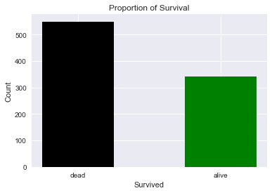

```python
# variable Survival 1-D visualization - histogram
vSurv = titanic_df[titanic_df['Survived']==1]['Survived'].count()
vDead = titanic_df[titanic_df['Survived']==0]['Survived'].count()

plt.bar([0,0.2],[vDead,vSurv],width=0.1,tick_label=['dead','alive'], color=['black','g'])
plt.xlabel('Survived')
plt.ylabel('Count')
plt.title('Proportion of Survival')
plt.show()
```

In this sample, the number of killed passengers is higher than the number of surviving passengers.

#### Variable 'Pclass'

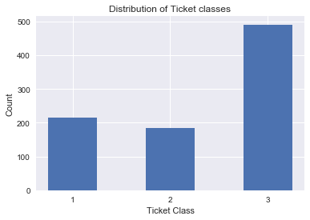

```python
# variable Pclass 1-D visualization

grouped_counts = titanic_df['Pclass'].value_counts().sort_index(ascending=True)

plt.bar([0,0.2, 0.4],grouped_counts,tick_label=grouped_counts.index, width=0.1)
plt.ylabel('Count')
plt.xlabel('Ticket Class')
plt.title('Distribution of Ticket classes')
plt.show()
```

```python
grouped_data = titanic_df.groupby('Pclass')
grouped_data['Survived'].describe()
```

| Pclass | count | mean | std | min | 25% | 50% | 75% | max |
| --- | --- | --- | --- | --- | --- | --- | --- | --- |
| 1 | 216.0 | 0.629630 | 0.484026 | 0.0 | 0.0 | 1.0 | 1.0 | 1.0 |
| 2 | 184.0 | 0.472826 | 0.500623 | 0.0 | 0.0 | 0.0 | 1.0 | 1.0 |
| 3 | 491.0 | 0.242363 | 0.428949 | 0.0 | 0.0 | 0.0 | 0.0 | 1.0 |

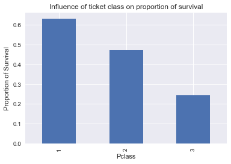

```python
grouped_data = titanic_df.groupby(['Pclass'])
pdplot=grouped_data['Survived'].mean().plot(kind='bar',legend=False)
pdplot.set_ylabel('Proportion of Survival')
pdplot.set_title('Influence of ticket class on proportion of survival')
```

The ticket class (Pclass, i.e. the socio-economic status) seems to have a strong impact on survival. The higher your class, the more likely you were to survive (based on the mean).

#### Variable 'Section'

```python
grouped_data = titanic_df.groupby('Section')
grouped_data['Survived'].describe()
```

| Section | count | mean | std | min | 25% | 50% | 75% | max |
| --- | --- | --- | --- | --- | --- | --- | --- | --- |
| A | 15.0 | 0.466667 | 0.516398 | 0.0 | 0.0 | 0.0 | 1.0 | 1.0 |
| B | 47.0 | 0.744681 | 0.440755 | 0.0 | 0.5 | 1.0 | 1.0 | 1.0 |
| C | 59.0 | 0.593220 | 0.495450 | 0.0 | 0.0 | 1.0 | 1.0 | 1.0 |
| D | 33.0 | 0.757576 | 0.435194 | 0.0 | 1.0 | 1.0 | 1.0 | 1.0 |
| E | 33.0 | 0.757576 | 0.435194 | 0.0 | 1.0 | 1.0 | 1.0 | 1.0 |
| F | 12.0 | 0.583333 | 0.514929 | 0.0 | 0.0 | 1.0 | 1.0 | 1.0 |
| G | 4.0 | 0.500000 | 0.577350 | 0.0 | 0.0 | 0.5 | 1.0 | 1.0 |
| T | 1.0 | 0.000000 | NaN | 0.0 | 0.0 | 0.0 | 0.0 | 0.0 |
| Unknown | 687.0 | 0.299854 | 0.458528 | 0.0 | 0.0 | 0.0 | 1.0 | 1.0 |

The section of the cabin has no discernable effect on survival; the mean survival probability per Section fluctuates quite a bit, but without a pattern.

#### Variable 'Sex'

```python
grouped_data = titanic_df.groupby('Sex')
grouped_data['Survived'].describe()
```

| Sex | count | mean | std | min | 25% | 50% | 75% | max |
| --- | --- | --- | --- | --- | --- | --- | --- | --- |
| female | 314.0 | 0.742038 | 0.438211 | 0.0 | 0.0 | 1.0 | 1.0 | 1.0 |
| male | 577.0 | 0.188908 | 0.391775 | 0.0 | 0.0 | 0.0 | 0.0 | 1.0 |

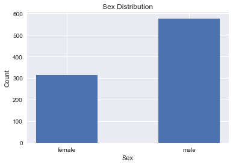

```python
# variables Sex 1-D visualization
grouped_counts = titanic_df['Sex'].value_counts().sort_index(ascending=True)

plt.bar([0,0.2],grouped_counts,tick_label=grouped_counts.index, width=0.1)
plt.ylabel('Count')
plt.xlabel('Sex')
plt.title('Sex Distribution')
plt.show()
```

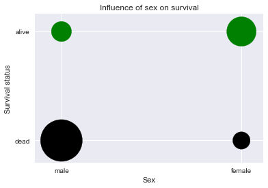

```python
# Survived - Sex 2-D visualization
def convert_sex_number(sex):
    u"""Converts character string to 0/1 integer flag"""
    iNum = 0
    if sex=='male' :
        iNum = 0
    else:
        iNum = 1
    return iNum

titanic_df['SexNum']=titanic_df['Sex'].apply(convert_sex_number)
grouped_data_df = titanic_df.groupby(['SexNum','Survived'],as_index=False).count()
plt.scatter(y=grouped_data_df['Survived'], x=grouped_data_df['SexNum'],
            s=grouped_data_df['Sex']*8,
            c=['black','g','black','g'])
plt.yticks( np.arange(2), ('dead', 'alive'))
plt.xticks( np.arange(2), ('male', 'female'))
plt.ylabel('Survival status')
plt.xlabel('Sex')
plt.title('Influence of sex on survival')
plt.show()
```

Sex is also an important determinant for the average survival probability. Lady passengers were on average much more likely to survive than men. The size of the circles shows the number of passengers in each category; the color indicates the survival status.

#### Variable 'Age'

The following table lists several statistical metrics regarding the proportion of survival per age type. NULL / NA values are excluded by the pandas.Series.describe() function.

```python
grouped_data = titanic_df.groupby('AgeType')
grouped_data['Survived'].describe()
```

| AgeType | count | mean | std | min | 25% | 50% | 75% | max |
| --- | --- | --- | --- | --- | --- | --- | --- | --- |
| Adults | 609.0 | 0.387521 | 0.487585 | 0.0 | 0.0 | 0.0 | 1.0 | 1.0 |
| Kids | 83.0 | 0.590361 | 0.494757 | 0.0 | 0.0 | 1.0 | 1.0 | 1.0 |
| Seniors | 22.0 | 0.227273 | 0.428932 | 0.0 | 0.0 | 0.0 | 0.0 | 1.0 |

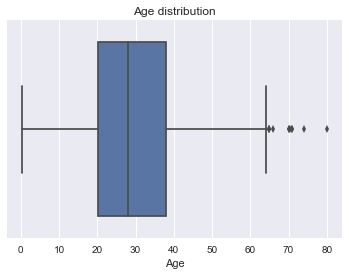

```python
# variable Age  1-D visualization
ax=sns.boxplot(titanic_df['Age'])
ax.set_title('Age distribution')
```

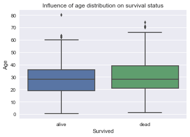

```python
# variable Age - Survived  2-D visualization
sSurv = titanic_df[titanic_df['Survived']==1]['Age']
sDead = titanic_df[titanic_df['Survived']==0]['Age']

ax=sns.boxplot(data=[sSurv, sDead])

plt.ylabel('Age')
plt.title('Influence of age distribution on survival status')
plt.xticks( np.arange(2), ('alive','dead'))
plt.xlabel('Survived')
```

Most of the passengers were between 20 and 40 years old. Unsurprisingly, kids (or generally younger passengers) were more likely to survive than other age groups. NULL / NA values are ignored.

#### Variable 'Family_Size'

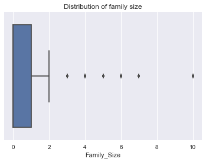

```python
# variable Family_Size 1-D visualization
ax=sns.boxplot(titanic_df['Family_Size'])
plt.title('Distribution of family size')
```

The most family sizes tend to be between 0 and 1 with some outliers for larger families.

```python
grouped_data = titanic_df.groupby('Family_Size')
grouped_data['Survived'].describe()
```

| Family_Size | count | mean | std | min | 25% | 50% | 75% | max |
| --- | --- | --- | --- | --- | --- | --- | --- | --- |
| 0 | 537.0 | 0.303538 | 0.460214 | 0.0 | 0.0 | 0.0 | 1.0 | 1.0 |
| 1 | 161.0 | 0.552795 | 0.498756 | 0.0 | 0.0 | 1.0 | 1.0 | 1.0 |
| 2 | 102.0 | 0.578431 | 0.496249 | 0.0 | 0.0 | 1.0 | 1.0 | 1.0 |
| 3 | 29.0 | 0.724138 | 0.454859 | 0.0 | 0.0 | 1.0 | 1.0 | 1.0 |
| 4 | 15.0 | 0.200000 | 0.414039 | 0.0 | 0.0 | 0.0 | 0.0 | 1.0 |
| 5 | 22.0 | 0.136364 | 0.351250 | 0.0 | 0.0 | 0.0 | 0.0 | 1.0 |
| 6 | 12.0 | 0.333333 | 0.492366 | 0.0 | 0.0 | 0.0 | 1.0 | 1.0 |
| 7 | 6.0 | 0.000000 | 0.000000 | 0.0 | 0.0 | 0.0 | 0.0 | 0.0 |
| 10 | 7.0 | 0.000000 | 0.000000 | 0.0 | 0.0 | 0.0 | 0.0 | 0.0 |

The family size seems to have an interesting impact on survival probabilities: passengers travelling alone (Family_Size=0) exhibit a lower survival probability than passengers travelling with a medium-sized family. Passengers with a large family (Family_Size>3) seem to have a diminished survival probability. However, the number of passengers with large families tend to be quite small, so this finding could also be a statistical artifact.

#### Multivariate Analysis

```python
grouped_data = titanic_df.groupby(['Sex','AgeType','Pclass'])
grouped_data['Survived'].describe()
```

| Sex | AgeType | Pclass | count | mean | std | min | 25% | 50% | 75% | max |
| --- | --- | --- | --- | --- | --- | --- | --- | --- | --- | --- |
| female | Adults | 1 | 80.0 | 0.975000 | 0.157110 | 0.0 | 1.0 | 1.0 | 1.0 | 1.0 |
|  |  | 2 | 64.0 | 0.906250 | 0.293785 | 0.0 | 1.0 | 1.0 | 1.0 | 1.0 |
|  |  | 3 | 71.0 | 0.422535 | 0.497479 | 0.0 | 0.0 | 0.0 | 1.0 | 1.0 |
|  | Kids | 1 | 3.0 | 0.666667 | 0.577350 | 0.0 | 0.5 | 1.0 | 1.0 | 1.0 |
|  |  | 2 | 10.0 | 1.000000 | 0.000000 | 1.0 | 1.0 | 1.0 | 1.0 | 1.0 |
|  |  | 3 | 30.0 | 0.533333 | 0.507416 | 0.0 | 0.0 | 1.0 | 1.0 | 1.0 |
|  | Seniors | 1 | 2.0 | 1.000000 | 0.000000 | 1.0 | 1.0 | 1.0 | 1.0 | 1.0 |
|  |  | 3 | 1.0 | 1.000000 | NaN | 1.0 | 1.0 | 1.0 | 1.0 | 1.0 |
| male | Adults | 1 | 86.0 | 0.418605 | 0.496224 | 0.0 | 0.0 | 0.0 | 1.0 | 1.0 |
|  |  | 2 | 87.0 | 0.057471 | 0.234090 | 0.0 | 0.0 | 0.0 | 0.0 | 1.0 |
|  |  | 3 | 221.0 | 0.131222 | 0.338409 | 0.0 | 0.0 | 0.0 | 0.0 | 1.0 |
|  | Kids | 1 | 3.0 | 1.000000 | 0.000000 | 1.0 | 1.0 | 1.0 | 1.0 | 1.0 |
|  |  | 2 | 9.0 | 1.000000 | 0.000000 | 1.0 | 1.0 | 1.0 | 1.0 | 1.0 |
|  |  | 3 | 28.0 | 0.321429 | 0.475595 | 0.0 | 0.0 | 0.0 | 1.0 | 1.0 |
|  | Seniors | 1 | 12.0 | 0.083333 | 0.288675 | 0.0 | 0.0 | 0.0 | 0.0 | 1.0 |
|  |  | 2 | 3.0 | 0.333333 | 0.577350 | 0.0 | 0.0 | 0.0 | 0.5 | 1.0 |
|  |  | 3 | 4.0 | 0.000000 | 0.000000 | 0.0 | 0.0 | 0.0 | 0.0 | 0.0 |

The factors Sex, AgeType and Pclass showed the strongest singular effects on survival probability, so let's examine their interaction. Many of the resulting 17 groups only have few passengers, so the statistical relevance is small. But some observations merit closer discussion:

- Rich ladies were almost guaranteed to survive
- Rich, adult gentlemen had an average survival probability, but other than that, adult men had an abysmal survival probability.

### 5.2 Question 2

```python
grouped_data = titanic_df.groupby(['AgeType'])
grouped_data['Fare'].describe()
```

| AgeType | count | mean | std | min | 25% | 50% | 75% | max |
| --- | --- | --- | --- | --- | --- | --- | --- | --- |
| Adults | 609.0 | 34.713457 | 55.020114 | 0.0000 | 7.925 | 13.50 | 32.50000 | 512.3292 |
| Kids | 83.0 | 32.785795 | 33.466438 | 7.2250 | 15.900 | 26.25 | 32.19375 | 211.3375 |
| Seniors | 22.0 | 41.371214 | 54.783357 | 6.2375 | 10.500 | 26.55 | 45.79170 | 263.0000 |

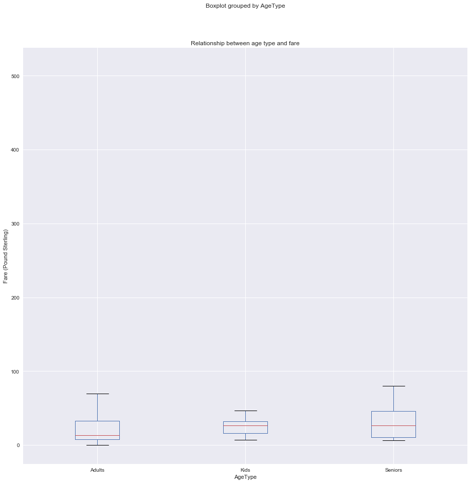

```python
# AgeType - Fare 2d visualization
titanic_df.boxplot(column='Fare', by='AgeType', figsize=(15,15))
plt.title('Relationship between age type and fare')
plt.ylabel('Fare (Pound Sterling)')
```

The above table only shows a weak link between age group and fare statistics. Seniors seems to have a slightly higher average fair, but their median fare is on par with that of kids. Adults have the widest range of fare values, which is not surprising as they are the largest of the three groups. The above boxplot demonstrates the skew in the fare distributions; there are some really large values, that stretch the y-axis.

## 6. Conclusion

### 6.1 Limitations of the analysis

- a high number of null values in the columns Age and Cabin makes it hard to draw conclusions from these columns that match those of other columns.
- this sample of small size makes it hard to generalize answers for the population; moreover, it is not clear, how the elements in the sample were drawn from the population. The sampling process could have led to a biased sample.
- Using group comparisons delivers descriptive statistics, but it won't allow the researcher to qualify the statistical significance of the perceived differences. A statistical test would be required for that.

### 6.2 Summary statistics and plot

The following chart summarizes the average survival probabilities for the two most important determinants, Sex and Pclass. The Python code for the bar chart is based on the review comments received for this project.

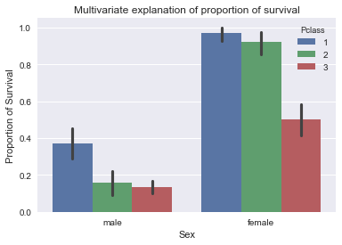

```python
sns.barplot(data=titanic_df, x="Sex", hue='Pclass', y='Survived', estimator=np.mean, ci=95);
plt.ylabel('Proportion of Survival');
plt.title('Multivariate explanation of proportion of survival')
plt.show()
```

The above bar chart allows the direct comparison of survival probabilities among different groups of passengers and visualizes the results obtained earlier. The wider the 95% confidence interval (black lines) of each bar, the more mixed and uneven are the chances of survival.

For instance, here's a group of swarm plots showing survival status according to age, gender, and ticket class: The Python code for the factorplot chart is based on the review comments received for this project.

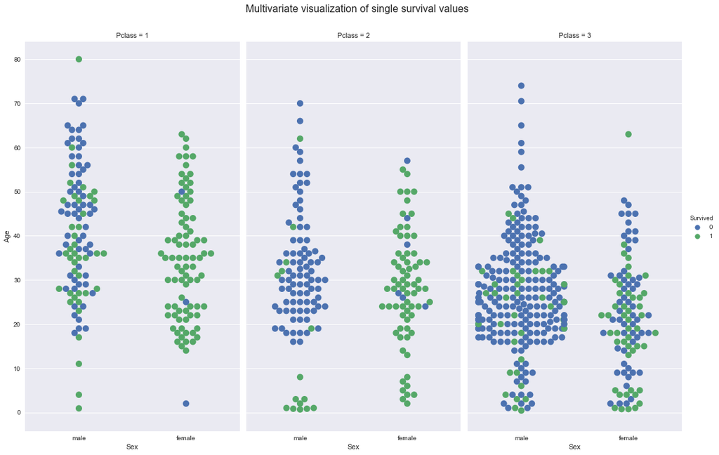

```python
g=sns.factorplot(data=titanic_df, col='Pclass', x='Sex', y='Age', hue='Survived',
               kind='swarm', size=10, aspect=0.5, s=10)
plt.yticks(np.arange(0,81,10));
g.fig.subplots_adjust(top=0.9)
g.fig.suptitle('Multivariate visualization of single survival values', fontsize=16)
```

### 6.3 Further Research

This paragraph briefly explains what other analyses may be performed on this data set based on what was presented in my report.

I would like to pick up on a topic suggestion of one of the reviewers: fare is a particularly tough variable to deal with in this data set. It is unknown whether it corresponds to the individual value paid by each passenger, or to the value paid for the ticket as a whole - which might include people traveling together (such as family members).

I would approach this additional analysis by looking at the (linear) regression between the Fare column and the columns SibSp,Parch and Family_Size. The regression delivers the coefficients and the intercept, which could give a hint to the tariff system, from which the fare was calculated.

## References

- https://d17h27t6h515a5.cloudfront.net/topher/2016/September/57e9a84c_titanic-data/titanic-data.csv
- https://triangleinequality.wordpress.com/2013/09/08/basic-feature-engineering-with-the-titanic-data/
- https://www.kaggle.com/c/titanic/data
- http://www.keyflux.com/titanic/facts.htm
- https://en.wikipedia.org/wiki/Level_of_measurement
- https://www.encyclopedia-titanica.org/titanic-deckplans/profile.html
- http://matplotlib.org/examples/pylab_examples/barchart_demo.html
- https://gallery.cortanaintelligence.com/Experiment/Methods-for-handling-missing-values-1